# EDA - Visualization

## Learning Objectives

After completing this lab, students will be able to:

- Create histograms and boxplots
- Generate scatterplots using ggplot2
- Identify outliers visually
- Perform correlation analysis
- Prepare a simple EDA report

## 1. Load Required Libraries

```r
# Install packages (run once)
# install.packages("tidyverse")
# install.packages("corrplot")

library(tidyverse)
library(corrplot)
```

tidyverse is a collection of R packages designed for data science that provides a consistent and user-friendly framework for data import, cleaning, wrangling, visualization, and analysis. It simplifies common data manipulation tasks and promotes the use of tidy data, where each variable is a column, each observation is a row, and each value occupies a single cell.

Some commonly used packages in the tidyverse include:

- readr – Import data
- dplyr – Data manipulation and wrangling
- tidyr – Data reshaping and tidy data
- ggplot2 – Data visualization

## 2. Load Dataset

We will use the built-in mtcars dataset.

```r
data(mtcars)
head(mtcars)
```

|  | mpg | cyl | disp | hp | drat | wt | qsec | vs | am | gear | carb |
| --- | --- | --- | --- | --- | --- | --- | --- | --- | --- | --- | --- |
| Mazda RX4 | 21.0 | 6 | 160 | 110 | 3.90 | 2.620 | 16.46 | 0 | 1 | 4 | 4 |
| Mazda RX4 Wag | 21.0 | 6 | 160 | 110 | 3.90 | 2.875 | 17.02 | 0 | 1 | 4 | 4 |
| Datsun 710 | 22.8 | 4 | 108 | 93 | 3.85 | 2.320 | 18.61 | 1 | 1 | 4 | 1 |
| Hornet 4 Drive | 21.4 | 6 | 258 | 110 | 3.08 | 3.215 | 19.44 | 1 | 0 | 3 | 1 |
| Hornet Sportabout | 18.7 | 8 | 360 | 175 | 3.15 | 3.440 | 17.02 | 0 | 0 | 3 | 2 |
| Valiant | 18.1 | 6 | 225 | 105 | 2.76 | 3.460 | 20.22 | 1 | 0 | 3 | 1 |

## 3. Understanding the Dataset

```r
str(mtcars)
```

```
'data.frame':   32 obs. of  11 variables:
 $ mpg : num  21 21 22.8 21.4 18.7 18.1 14.3 24.4 22.8 19.2 ...
 $ cyl : num  6 6 4 6 8 6 8 4 4 6 ...
 $ disp: num  160 160 108 258 360 ...
 $ hp  : num  110 110 93 110 175 105 245 62 95 123 ...
 $ drat: num  3.9 3.9 3.85 3.08 3.15 2.76 3.21 3.69 3.92 3.92 ...
 $ wt  : num  2.62 2.88 2.32 3.21 3.44 ...
 $ qsec: num  16.5 17 18.6 19.4 17 ...
 $ vs  : num  0 0 1 1 0 1 0 1 1 1 ...
 $ am  : num  1 1 1 0 0 0 0 0 0 0 ...
 $ gear: num  4 4 4 3 3 3 3 4 4 4 ...
 $ carb: num  4 4 1 1 2 1 4 2 2 4 ...
```

```r
dim(mtcars)
```

```
[1] 32 11
```

```r
summary(mtcars)
```

```
      mpg             cyl             disp             hp             drat
 Min.   :10.40   Min.   :4.000   Min.   : 71.1   Min.   : 52.0   Min.   :2.760
 1st Qu.:15.43   1st Qu.:4.000   1st Qu.:120.8   1st Qu.: 96.5   1st Qu.:3.080
 Median :19.20   Median :6.000   Median :196.3   Median :123.0   Median :3.695
 Mean   :20.09   Mean   :6.188   Mean   :230.7   Mean   :146.7   Mean   :3.597
 3rd Qu.:22.80   3rd Qu.:8.000   3rd Qu.:326.0   3rd Qu.:180.0   3rd Qu.:3.920
 Max.   :33.90   Max.   :8.000   Max.   :472.0   Max.   :335.0   Max.   :4.930
       wt             qsec             vs               am              gear
 Min.   :1.513   Min.   :14.50   Min.   :0.0000   Min.   :0.0000   Min.   :3.000
 1st Qu.:2.581   1st Qu.:16.89   1st Qu.:0.0000   1st Qu.:0.0000   1st Qu.:3.000
 Median :3.325   Median :17.71   Median :0.0000   Median :0.0000   Median :4.000
 Mean   :3.217   Mean   :17.85   Mean   :0.4375   Mean   :0.4062   Mean   :3.688
 3rd Qu.:3.610   3rd Qu.:18.90   3rd Qu.:1.0000   3rd Qu.:1.0000   3rd Qu.:4.000
 Max.   :5.424   Max.   :22.90   Max.   :1.0000   Max.   :1.0000   Max.   :5.000
      carb
 Min.   :1.000
 1st Qu.:2.000
 Median :2.000
 Mean   :2.812
 3rd Qu.:4.000
 Max.   :8.000
```

**Questions**

- How many observations are there?
- How many variables are there?
- Which variables are numerical?

## 4. Histogram

A histogram shows the distribution of a numerical variable.

Example: Miles per Gallon (mpg)

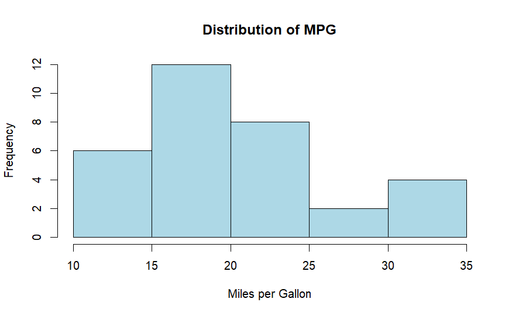

```r
hist(
  mtcars$mpg,
  main = "Distribution of MPG",
  xlab = "Miles per Gallon",
  col = "lightblue",
  border = "black"
)
```

**Interpretation**

- Is the distribution symmetric?
- Is it positively or negatively skewed?
- Where are most observations concentrated?

### Histogram using ggplot2

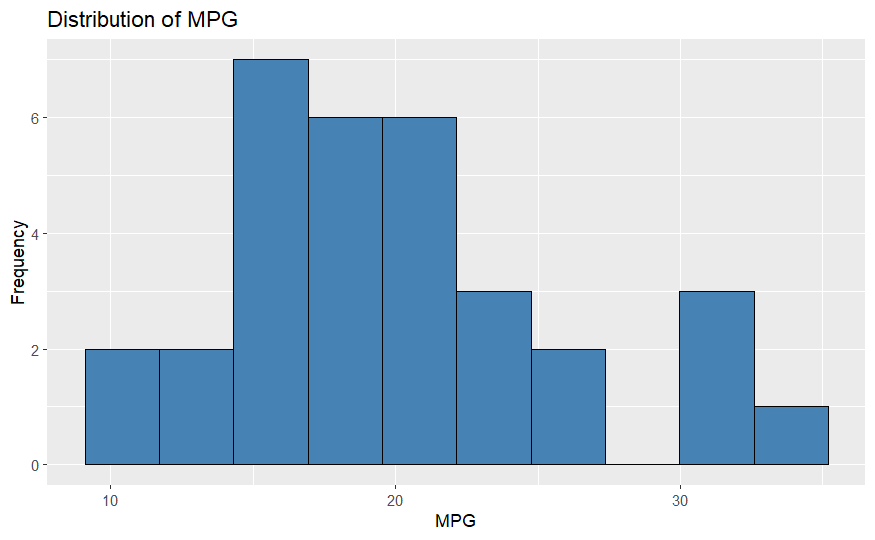

```r
ggplot(
  mtcars,
  aes(x = mpg)
) +
  geom_histogram(
    bins = 10,
    fill = "steelblue",
    color = "black"
  ) +
  labs(
    title = "Distribution of MPG",
    x = "MPG",
    y = "Frequency"
  )
```

## 5. Boxplot

A boxplot summarizes:

- Minimum
- Q1
- Median
- Q3
- Maximum
- Outliers

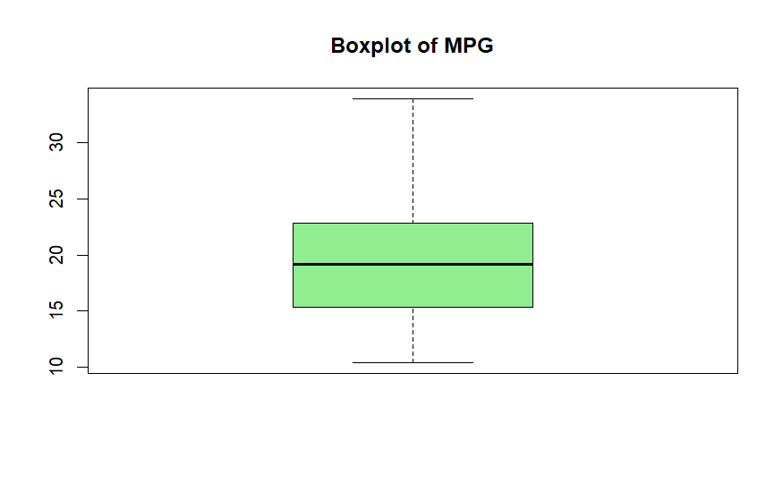

```r
boxplot(
  mtcars$mpg,
  main = "Boxplot of MPG",
  col = "lightgreen"
)
```

### Boxplot using ggplot2

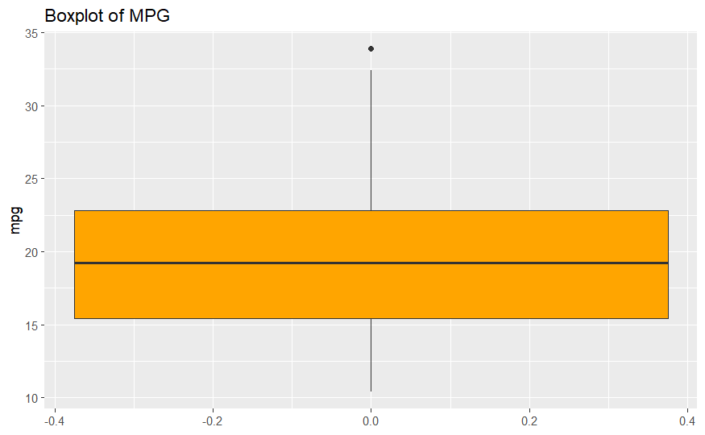

```r
ggplot(
  mtcars,
  aes(y = mpg)
) +
  geom_boxplot(
    fill = "orange"
  ) +
  labs(
    title = "Boxplot of MPG"
  )
```

## 6. Visual Identification of Outliers

Create a sample dataset with an obvious outlier.

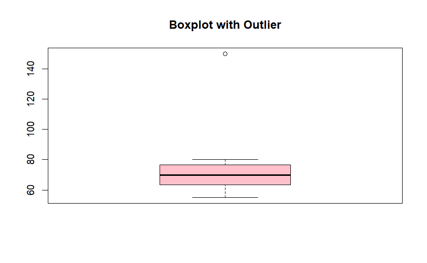

```r
scores <- c(
  55, 60, 62, 65, 68,
  70, 72, 75, 78, 80,
  150
)

boxplot(
  scores,
  main = "Boxplot with Outlier",
  col = "pink"
)
```

**Discussion**

- Which value appears to be an outlier?
- Why does it appear separately?

### Variation and Distribution Spanned by Boxplots

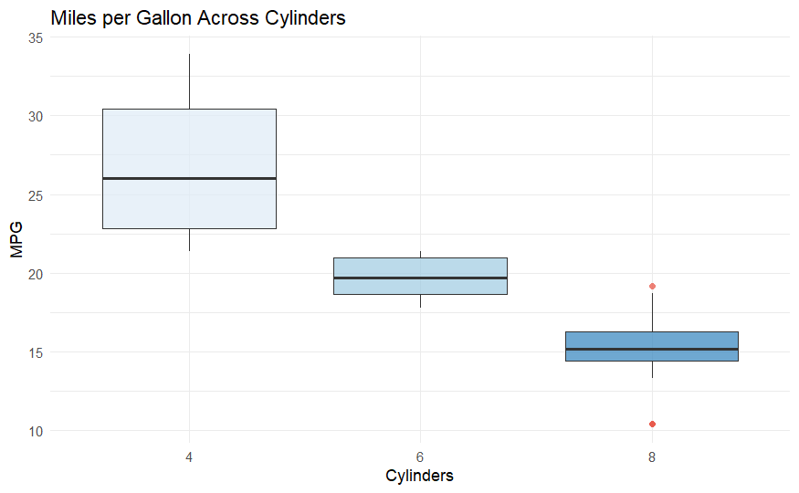

```r
# Comparing diamond prices across different cut qualities
ggplot(mtcars, aes(x = as.factor(cyl), y = mpg, fill = as.factor(cyl))) +
  geom_boxplot(alpha = 0.7, outlier.color = "#E74C3C", outlier.shape = 16) +
  scale_fill_brewer(palette = "Blues") +
  labs(
    title = "Miles per Gallon Across Cylinders",
    x = "Cylinders",
    y = "MPG",
    fill = "Cylinder Legend"
  ) +
  theme_minimal() +
  theme(legend.position = "none")
```

### Detecting Outliers Using IQR

```r
Q1 <- quantile(scores, 0.25)

Q3 <- quantile(scores, 0.75)

IQR_value <- IQR(scores)

lower <- Q1 - 1.5 * IQR_value

upper <- Q3 + 1.5 * IQR_value

scores[
  scores < lower |
  scores > upper
]
```

```
[1] 150
```

## 7. Scatterplots using ggplot2

Scatterplots help visualize relationships between variables.

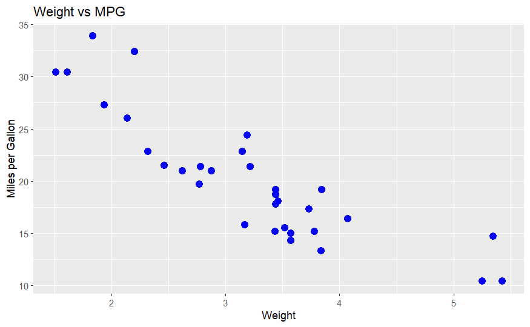

```r
ggplot(
  mtcars,
  aes(
    x = wt,
    y = mpg
  )
) +
  geom_point(
    size = 3,
    color = "blue"
  ) +
  labs(
    title = "Weight vs MPG",
    x = "Weight",
    y = "Miles per Gallon"
  )
```

**Questions**

- Is there a positive or negative relationship?
- Is the relationship strong or weak?

## 8. Adding a Trend Line

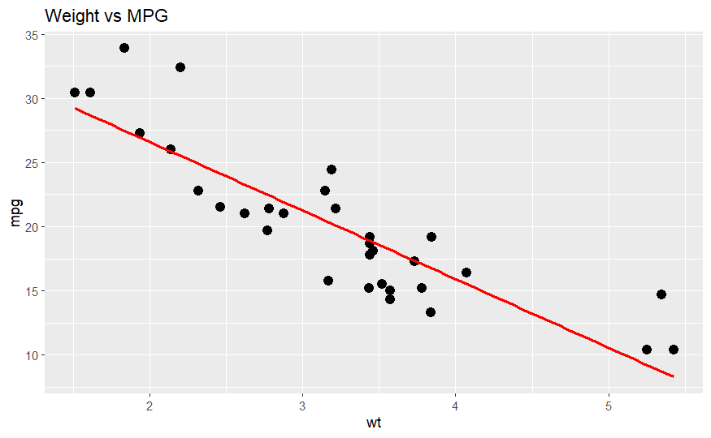

```r
ggplot(
  mtcars,
  aes(
    x = wt,
    y = mpg
  )
) +
  geom_point(size = 3) +
  geom_smooth(
    method = "lm",
    se = FALSE,
    color = "red"
  ) +
  labs(
    title = "Weight vs MPG"
  )
```

**Interpretation**

Does MPG increase or decrease as weight increases?

## 9. Correlation Analysis

**Correlation Coefficient**

```r
cor(
  mtcars$wt,
  mtcars$mpg
)
```

```
[1] -0.8676594
```

**Interpretation**

| Correlation | Interpretation |
| --- | --- |
| +1 | Perfect positive |
| 0 | No relationship |
| -1 | Perfect negative |

**Correlation Matrix**

```r
cor_matrix <- cor(mtcars)

cor_matrix
```

```
            mpg        cyl       disp         hp        drat         wt        qsec
mpg   1.0000000 -0.8521620 -0.8475514 -0.7761684  0.68117191 -0.8676594  0.41868403
cyl  -0.8521620  1.0000000  0.9020329  0.8324475 -0.69993811  0.7824958 -0.59124207
disp -0.8475514  0.9020329  1.0000000  0.7909486 -0.71021393  0.8879799 -0.43369788
hp   -0.7761684  0.8324475  0.7909486  1.0000000 -0.44875912  0.6587479 -0.70822339
drat  0.6811719 -0.6999381 -0.7102139 -0.4487591  1.00000000 -0.7124406  0.09120476
wt   -0.8676594  0.7824958  0.8879799  0.6587479 -0.71244065  1.0000000 -0.17471588
qsec  0.4186840 -0.5912421 -0.4336979 -0.7082234  0.09120476 -0.1747159  1.00000000
vs    0.6640389 -0.8108118 -0.7104159 -0.7230967  0.44027846 -0.5549157  0.74453544
am    0.5998324 -0.5226070 -0.5912270 -0.2432043  0.71271113 -0.6924953 -0.22986086
gear  0.4802848 -0.4926866 -0.5555692 -0.1257043  0.69961013 -0.5832870 -0.21268223
carb -0.5509251  0.5269883  0.3949769  0.7498125 -0.09078980  0.4276059 -0.65624923
             vs          am       gear        carb
mpg   0.6640389  0.59983243  0.4802848 -0.55092507
cyl  -0.8108118 -0.52260705 -0.4926866  0.52698829
disp -0.7104159 -0.59122704 -0.5555692  0.39497686
hp   -0.7230967 -0.24320426 -0.1257043  0.74981247
drat  0.4402785  0.71271113  0.6996101 -0.09078980
wt   -0.5549157 -0.69249526 -0.5832870  0.42760594
qsec  0.7445354 -0.22986086 -0.2126822 -0.65624923
vs    1.0000000  0.16834512  0.2060233 -0.56960714
am    0.1683451  1.00000000  0.7940588  0.05753435
gear  0.2060233  0.79405876  1.0000000  0.27407284
carb -0.5696071  0.05753435  0.2740728  1.00000000
```

**Visualizing Correlation Matrix**

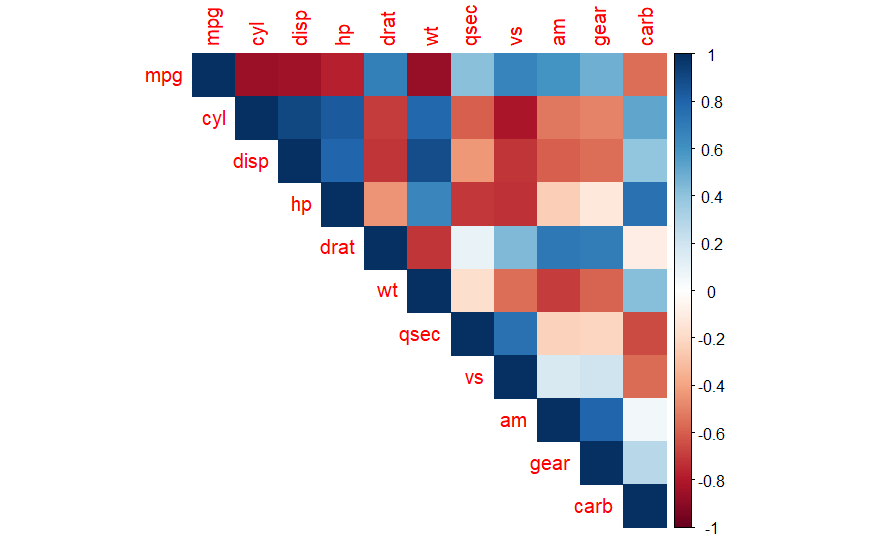

```r
corrplot(
  cor_matrix,
  method = "color",
  type = "upper"
)
```

**Questions**

- Which variables are strongly correlated?
- Which variables have weak correlations?

## 10. Pairwise Scatterplots

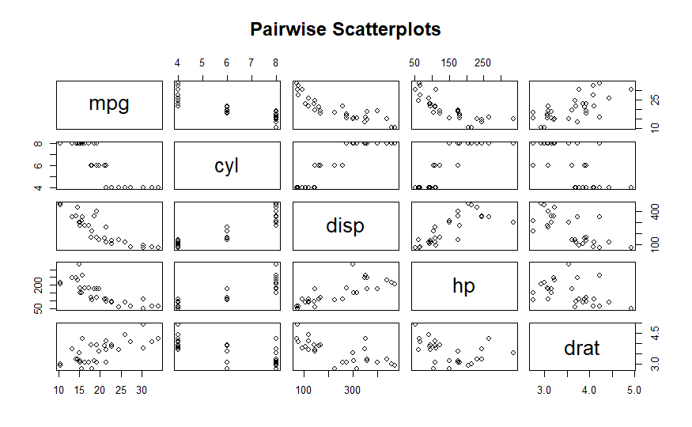

```r
pairs(
  mtcars[, 1:5],
  main = "Pairwise Scatterplots"
)
```

## Exercises

### Exercise 1

Perform EDA on the variable:

`mtcars$hp`

Tasks:

1. Create a histogram.
2. Create a boxplot.
3. Identify any outliers.
4. Calculate summary statistics.
5. Describe the distribution.

### Exercise 2

Using the iris dataset: `data(iris)`

Perform the following:

1. Create a histogram of Sepal Length.
2. Create a boxplot of Petal Length.
3. Create a scatterplot of Sepal Length vs Petal Length.
4. Calculate the correlation between Sepal Length and Petal Length.
5. Write a short EDA report (5–8 bullet points).

## Home work

Choose a public dataset from Kaggle or UCI and prepare a one-page EDA report containing:

- Dataset description
- Summary statistics
- Histogram
- Boxplot
- Scatterplot
- Correlation analysis
- Three key findings